# svc_norm.r

jflournoy

Mon Aug 10 12:24:53 2015

This is an EFA for the ratings of the self on all items. Only 70 of the 77 have totally complete data, and to be conservative, I’m just looking at those 70. We don’t lose too much without those 7 and it’s easier to satisfy assumptions of EFA without missing data. Haven’t looked closely at what they’re missing yet though.

```
## [1]  77 239
```

These histograms by themselves tell a really interesting story – you can see that there is a some overlap between Acc and Cont ratings, but some items distinguish between them. These line up with a lot of our *a priori* ideas – see anger and jealousy. Pretty cool.

Aside from the status items, you also can see the scores on depression and substance use, among other things. Keep in mind the middle 2 CES_D items are reverse coded. SES ladder is mostly between 3-7 on a 9 point scale.

[figure not shown]

The scree plot shows *very* clearly a 4 factor solution will account for most of the variance, with no real gain if we increase beyond 4.

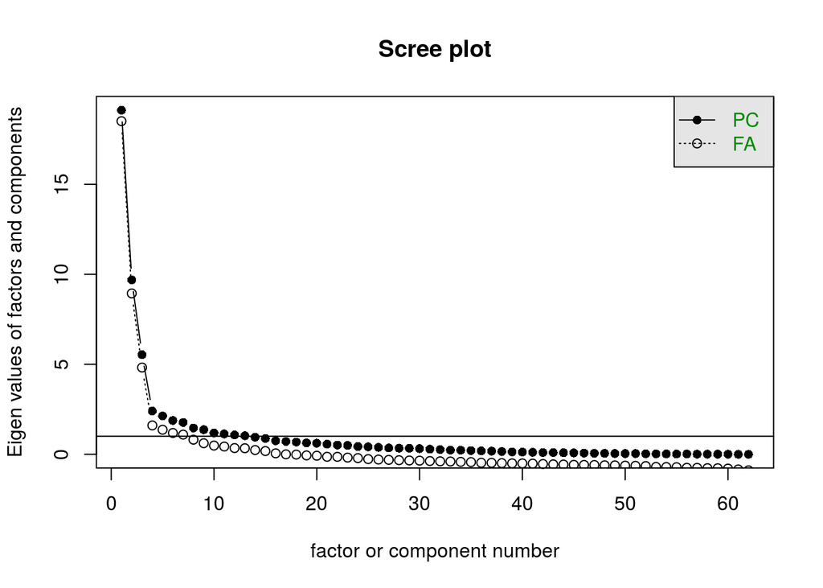

The raw output, if you like, but see below for a prettier table.

```
## Factor Analysis using method =  ml
## Call: fa(r = selfRateDatCompleteCor, nfactors = 4, n.obs = nobs, rotate = "oblimin",
##     scores = "tenBerge", fm = "ml")
## Standardized loadings (pattern matrix) based upon correlation matrix
##                    item   ML2   ML1   ML3   ML4   h2   u2 com
## nice_Self            40  0.89  0.11 -0.15  0.16 0.84 0.16 1.2
## considerate_Self     14  0.85  0.19 -0.11  0.08 0.71 0.29 1.1
## helpful_Self         28  0.85  0.01 -0.03  0.10 0.75 0.25 1.0
## caring_Self          11  0.80  0.01 -0.05  0.07 0.67 0.33 1.0
## genuine_Self         25  0.79 -0.06  0.09 -0.15 0.63 0.37 1.1
## welcoming_Self       62  0.77 -0.10 -0.10  0.08 0.72 0.28 1.1
## respectful_Self      47  0.76 -0.05  0.05 -0.41 0.69 0.31 1.6
## giving_Self          26  0.75 -0.07 -0.06 -0.05 0.63 0.37 1.0
## sympathetic_Self     58  0.73  0.01 -0.12 -0.06 0.57 0.43 1.1
## friendly_Self        23  0.70 -0.07 -0.13  0.25 0.67 0.33 1.4
## trustworthy_Self     60  0.70 -0.06 -0.17  0.17 0.64 0.36 1.3
## loyal_Self           37  0.70  0.02  0.00 -0.08 0.47 0.53 1.0
## fair_Self            20  0.62 -0.12 -0.16 -0.20 0.52 0.48 1.4
## humble_Self          30  0.59  0.22 -0.15 -0.12 0.38 0.62 1.5
## studious_Self        57  0.52  0.03  0.04 -0.31 0.32 0.68 1.7
## honest_Self          29  0.49 -0.22 -0.12 -0.06 0.39 0.61 1.6
## smart_Self           53  0.48 -0.01 -0.06  0.07 0.25 0.75 1.1
## calm_Self            10  0.47 -0.35 -0.07 -0.10 0.46 0.54 2.0
## comforting_Self      12  0.45 -0.26 -0.09  0.18 0.43 0.57 2.0
## patient_Self         42  0.43 -0.19 -0.16  0.00 0.33 0.67 1.6
## motivated_Self       39  0.40 -0.38 -0.01 -0.30 0.42 0.58 2.9
## depressed_Self       19  0.14  0.98  0.13  0.24 0.86 0.14 1.2
## lonely_Self          35  0.12  0.89  0.20 -0.07 0.81 0.19 1.1
## insecure_Self        31  0.05  0.88  0.12  0.01 0.76 0.24 1.0
## awkward_Self          7  0.14  0.86  0.09  0.07 0.66 0.34 1.1
## trendy_Self          59  0.11 -0.81  0.28 -0.10 0.74 0.26 1.3
## confident_Self       13  0.20 -0.73  0.14  0.12 0.74 0.26 1.3
## loner_Self           36 -0.03  0.73  0.10 -0.25 0.71 0.29 1.3
## popular_Self         45  0.27 -0.69  0.21  0.08 0.73 0.27 1.5
## plain_Self           43  0.05  0.65  0.08 -0.02 0.42 0.58 1.0
## social_Self          55  0.25 -0.63  0.23  0.28 0.80 0.20 2.0
## shy_Self             52  0.20  0.59  0.03 -0.38 0.55 0.45 2.0
## ugly_Self            61 -0.13  0.55  0.26 -0.18 0.53 0.47 1.8
## boring _Self          8 -0.06  0.55  0.18 -0.14 0.42 0.58 1.4
## outgoing_Self        41  0.18 -0.55  0.22  0.20 0.55 0.45 1.9
```

[output cut: 48 more lines]

[output not shown]

The four factors are pretty interpretable, if you ask me.

1. First (ML2), we have prosociality: caring, fair, helpful, loyal (guidelines for a model girl scout, basically).
2. Second (ML1), is surgency/dynamism (note that depression is the highest loading item, so positive items are actually given negative loadings): not depressed, lonely, or insecure; trendy, confident, popular, social.
3. Third (ML3), we have…aggression? Rude, mean, bossy, snobby, as well as lazy and fake.
4. Finally, fourth (ML4), daring, risky, adventurous, and not rule following.

These factors are allowed to correlate, so if you’re interested, scroll up to the raw output.

|  | ML2 | ML1 | ML3 | ML4 |
| --- | --- | --- | --- | --- |
| nice_Self | 0.89 | 0.11 | -0.15 | 0.16 |
| considerate_Self | 0.85 | 0.19 | -0.11 |  |
| helpful_Self | 0.85 |  |  |  |
| caring_Self | 0.80 |  |  |  |
| genuine_Self | 0.79 |  |  | -0.15 |
| welcoming_Self | 0.77 | -0.10 | -0.10 |  |
| respectful_Self | 0.76 |  |  | -0.41 |
| giving_Self | 0.75 |  |  |  |
| sympathetic_Self | 0.73 |  | -0.12 |  |
| friendly_Self | 0.70 |  | -0.13 | 0.25 |
| trustworthy_Self | 0.70 |  | -0.17 | 0.17 |
| loyal_Self | 0.70 |  |  |  |
| fair_Self | 0.62 | -0.12 | -0.16 | -0.20 |
| humble_Self | 0.59 | 0.22 | -0.15 | -0.12 |
| studious_Self | 0.52 |  |  | -0.31 |
| honest_Self | 0.49 | -0.22 | -0.12 |  |
| smart_Self | 0.48 |  |  |  |
| calm_Self | 0.47 | -0.35 |  |  |
| comforting_Self | 0.45 | -0.26 |  | 0.18 |
| patient_Self | 0.43 | -0.19 | -0.16 |  |
| motivated_Self | 0.40 | -0.38 |  | -0.30 |
| depressed_Self | 0.14 | 0.98 | 0.13 | 0.24 |
| lonely_Self | 0.12 | 0.89 | 0.20 |  |
| insecure_Self |  | 0.88 | 0.12 |  |
| awkward_Self | 0.14 | 0.86 |  |  |
| trendy_Self | 0.11 | -0.81 | 0.28 | -0.10 |
| confident_Self | 0.20 | -0.73 | 0.14 | 0.12 |
| loner_Self |  | 0.73 |  | -0.25 |
| popular_Self | 0.27 | -0.69 | 0.21 |  |
| plain_Self |  | 0.65 |  |  |
| social_Self | 0.25 | -0.63 | 0.23 | 0.28 |
| shy_Self | 0.20 | 0.59 |  | -0.38 |
| ugly_Self | -0.13 | 0.55 | 0.26 | -0.18 |
| boring _Self |  | 0.55 | 0.18 | -0.14 |
| outgoing_Self | 0.18 | -0.55 | 0.22 | 0.20 |
| admired_Self | 0.31 | -0.52 | 0.25 | 0.28 |
| leader_Self | 0.16 | -0.52 | 0.31 |  |
| flirty_Self | 0.11 | -0.51 | 0.22 | 0.32 |
| pushover_Self |  | 0.50 | 0.15 | -0.18 |
| attractive_Self | 0.33 | -0.49 | 0.11 | 0.29 |
| poor_Self | -0.28 | 0.48 | 0.21 |  |
| cool_Self | 0.37 | -0.46 | 0.40 | 0.23 |
| funny_Self | 0.33 | -0.45 | 0.12 | 0.18 |
| athletic_Self | 0.24 | -0.28 |  |  |
| rude_Self | -0.15 |  | 0.80 |  |
| mean_Self | -0.31 |  | 0.77 |  |
| bossy_Self |  | -0.16 | 0.75 |  |
| angry_Self |  | 0.33 | 0.72 |  |
| snobby_Self | -0.27 |  | 0.72 | 0.15 |
| controlling_Self |  | -0.32 | 0.70 |  |
| agressive_Self | -0.24 |  | 0.67 | 0.18 |
| grumpy_Self |  | 0.42 | 0.64 |  |
| jealous_Self |  | 0.36 | 0.62 |  |
| selfish_Self | -0.28 | 0.14 | 0.57 |  |
| lazy_Self | -0.14 | 0.19 | 0.54 |  |
| fake_Self | -0.33 | 0.21 | 0.46 |  |
| dependent_Self | 0.32 | 0.27 | 0.43 |  |
| stubborn_Self |  |  | 0.39 | 0.21 |
| daring_Self | 0.15 |  | 0.16 | 0.69 |
| rule-follower_Self | 0.51 |  | 0.23 | -0.56 |
| risky_Self |  |  | 0.25 | 0.54 |
| adventurous_Self | 0.32 | -0.27 | 0.21 | 0.47 |

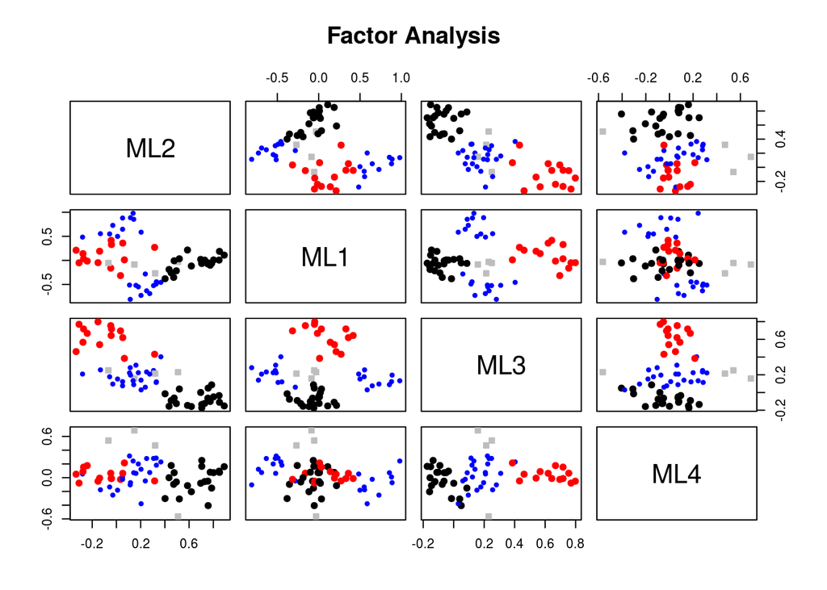

Now I correlate self rated accepted and controversial status with these factor scores.

SelfPop_1 is controversial, and SelfPop_2 is accepted.

```
##                                                                                                                        SelfPop_1
## 1 Think again about high school. For each type, select the option that corresponds to how well it d...-Controversial high status
##                                                                                                                   SelfPop_2
## 1 Think again about high school. For each type, select the option that corresponds to how well it d...-Accepted high status
```

We see accepted status is highly correlated with the surgency/dynamism component (remember, it’s reversed because of the depression item).

We also see that controversial status is correlated with aggression and slightly with risk-taking.

This gets more interesting in the regressions.

```
## Call:corr.test(x = as.data.frame(selfPopDat), y = as.data.frame(predict(selfRateFA,
##     selfRateDat)), use = "pairwise.complete.obs")
## Correlation matrix
##              V1    V2   V3   V4
## SelfPop_1 -0.16  0.08 0.50 0.27
## SelfPop_2  0.18 -0.70 0.09 0.18
## Sample Size
##           V1 V2 V3 V4
## SelfPop_1 68 68 68 68
## SelfPop_2 70 70 70 70
## Probability values  adjusted for multiple tests.
##             V1   V2   V3   V4
## SelfPop_1 0.63 0.91 0.00 0.17
## SelfPop_2 0.63 0.00 0.91 0.63
##
##  To see confidence intervals of the correlations, print with the short=FALSE option
```

Here’s the raw output for regressing controversial status on the component scores – see below for a table with CIs.

```
##
## Call: rlm(formula = selfPopDat[, c("SelfPop_1")] ~ predict(selfRateFA,
##     selfRateDat))
## Residuals:
##      Min       1Q   Median       3Q      Max
## -2.81873 -0.64302 -0.06092  0.53851  3.31691
##
## Coefficients:
##                                   Value   Std. Error t value
## (Intercept)                        2.2820  0.1461    15.6163
## predict(selfRateFA, selfRateDat)1 -0.3141  0.1454    -2.1600
## predict(selfRateFA, selfRateDat)2  0.1490  0.1444     1.0317
## predict(selfRateFA, selfRateDat)3  0.9047  0.1469     6.1587
## predict(selfRateFA, selfRateDat)4  0.3727  0.1463     2.5478
##
## Residual standard error: 0.8959 on 63 degrees of freedom
##   (9 observations deleted due to missingness)
```

Controversial status relation with component scores, bootstrapped CIs

| component | est | lower 95% | upper 95% |
| --- | --- | --- | --- |
| 1 | -0.31 | -0.75 | -0.03 |
| 2 | 0.15 | -0.11 | 0.52 |
| 3 | 0.90 | 0.46 | 1.17 |
| 4 | 0.37 | -0.09 | 0.78 |

Here’s the raw output for an rlm of accepted status on the component scores. Again, scroll down for a nice table.

```
##
## Call: rlm(formula = selfPopDat[, c("SelfPop_2")] ~ predict(selfRateFA,
##     selfRateDat))
## Residuals:
##      Min       1Q   Median       3Q      Max
## -2.67335 -0.57567  0.06995  0.51652  2.99395
##
## Coefficients:
##                                   Value   Std. Error t value
## (Intercept)                        3.5924  0.1351    26.5820
## predict(selfRateFA, selfRateDat)1  0.3234  0.1354     2.3877
## predict(selfRateFA, selfRateDat)2 -1.3161  0.1343    -9.8011
## predict(selfRateFA, selfRateDat)3  0.1860  0.1370     1.3579
## predict(selfRateFA, selfRateDat)4  0.1836  0.1355     1.3556
##
## Residual standard error: 0.8273 on 65 degrees of freedom
##   (7 observations deleted due to missingness)
```

Accepted status is significantly predicted by higher prosocial scores and higher surgency scores (again, not reversal of this component). Agression and risk-taking are both positive and non-significant.

Accepted status relation with component scores, bootstrapped CIs

| component | est | lower 95% | upper 95% |
| --- | --- | --- | --- |
| 1 | 0.32 | 0.02 | 0.55 |
| 2 | -1.32 | -1.58 | -0.92 |
| 3 | 0.19 | -0.08 | 0.48 |
| 4 | 0.18 | -0.36 | 0.71 |